# ANCOVA test for leitura (engajamento no leitura)

Geiser C. Challco geiser@alumni.usp.br

- Descriptive Statistics of Initial Data
- Checking of Assumptions
  - Assumption: Normality distribution of data
  - Assumption: Homogeneity of data distribution
- Computation of ANCOVA test and Pairwise Comparison
  - ANCOVA tests for one factor
  - ANCOVA tests for two factors
  - ANCOVA tests for grupo=“Experimental”
  - Pairwise comparisons for one factor
    - factor: **grupo**
    - factor: **genero**
    - factor: **idade**
    - factor: **zona.participante**
    - factor: **escola**
    - factor: **zona.escola**
  - Pairwise comparisons for two factors
    - factores: **grupo:genero**
    - factores: **grupo:idade**
    - factores: **grupo:zona.participante**
    - factores: **grupo:escola**
    - factores: **grupo:zona.escola**
  - Pairwise comparisons for grupo=“Experimental”
    - factores: **grupo=“Experimental”:monitor**
    - factores: **grupo=“Experimental”:monitor.genero**
    - factores: **grupo=“Experimental”:monitor.area**
    - factores: **grupo=“Experimental”:monitor.formacao**
    - factores: **grupo=“Experimental”:monitor.experiencia**

**NOTE**

- Teste ANCOVA para determinar se houve diferenças significativas em referência ao engajamento no leitura (medido como estado de fluxo).
- ANCOVA test to determine whether there were significant differences in reference to engagement in leitura (measured as flow state).

# Descriptive Statistics of Initial Data

| grupo | genero | idade | zona.participante | escola | zona.escola | variable | n | mean | median | min | max | sd | se | ci | iqr |
| --- | --- | --- | --- | --- | --- | --- | --- | --- | --- | --- | --- | --- | --- | --- | --- |
| Controle | F |  |  |  |  | fss.leitura | 60 | 3.521 | 3.611 | 2.556 | 4.222 | 0.418 | 0.054 | 0.108 | 0.583 |
| Controle | M |  |  |  |  | fss.leitura | 65 | 3.393 | 3.333 | 2.000 | 4.556 | 0.526 | 0.065 | 0.130 | 0.778 |
| Experimental | F |  |  |  |  | fss.leitura | 57 | 3.642 | 3.667 | 2.556 | 4.778 | 0.527 | 0.070 | 0.140 | 0.667 |
| Experimental | M |  |  |  |  | fss.leitura | 76 | 3.345 | 3.375 | 1.667 | 4.556 | 0.549 | 0.063 | 0.126 | 0.556 |
| Controle | F |  |  |  |  | dfs.leitura | 60 | 3.595 | 3.667 | 2.444 | 4.556 | 0.536 | 0.069 | 0.138 | 0.889 |
| Controle | M |  |  |  |  | dfs.leitura | 65 | 3.524 | 3.556 | 2.222 | 4.778 | 0.530 | 0.066 | 0.131 | 0.667 |
| Experimental | F |  |  |  |  | dfs.leitura | 57 | 3.593 | 3.667 | 2.333 | 4.875 | 0.528 | 0.070 | 0.140 | 0.444 |
| Experimental | M |  |  |  |  | dfs.leitura | 76 | 3.401 | 3.354 | 1.667 | 4.889 | 0.576 | 0.066 | 0.132 | 0.798 |
| Controle |  | 10y |  |  |  | fss.leitura | 24 | 3.541 | 3.667 | 2.667 | 4.222 | 0.406 | 0.083 | 0.172 | 0.472 |
| Controle |  | 11y |  |  |  | fss.leitura | 67 | 3.487 | 3.556 | 2.222 | 4.556 | 0.439 | 0.054 | 0.107 | 0.667 |
| Controle |  | 12y |  |  |  | fss.leitura | 18 | 3.437 | 3.278 | 2.556 | 4.556 | 0.611 | 0.144 | 0.304 | 0.889 |
| Controle |  | 13y |  |  |  | fss.leitura | 7 | 3.032 | 3.111 | 2.000 | 3.444 | 0.512 | 0.194 | 0.474 | 0.444 |
| Controle |  | 14y |  |  |  | fss.leitura | 1 | 3.556 | 3.556 | 3.556 | 3.556 |  |  |  | 0.000 |
| Controle |  | 15y |  |  |  | fss.leitura | 1 | 2.444 | 2.444 | 2.444 | 2.444 |  |  |  | 0.000 |
| Controle |  | 16y |  |  |  | fss.leitura | 1 | 2.667 | 2.667 | 2.667 | 2.667 |  |  |  | 0.000 |
| Controle |  |  |  |  |  | fss.leitura | 6 | 3.574 | 3.556 | 3.111 | 4.222 | 0.406 | 0.166 | 0.426 | 0.472 |
| Experimental |  | 10y |  |  |  | fss.leitura | 25 | 3.422 | 3.556 | 1.667 | 4.444 | 0.602 | 0.120 | 0.248 | 0.556 |
| Experimental |  | 11y |  |  |  | fss.leitura | 80 | 3.519 | 3.500 | 1.667 | 4.778 | 0.579 | 0.065 | 0.129 | 0.767 |
| Experimental |  | 12y |  |  |  | fss.leitura | 16 | 3.477 | 3.444 | 2.667 | 4.111 | 0.430 | 0.108 | 0.229 | 0.563 |
| Experimental |  | 13y |  |  |  | fss.leitura | 9 | 3.287 | 3.333 | 2.556 | 4.375 | 0.507 | 0.169 | 0.389 | 0.333 |
| Experimental |  | 14y |  |  |  | fss.leitura | 1 | 3.375 | 3.375 | 3.375 | 3.375 |  |  |  | 0.000 |
| Experimental |  |  |  |  |  | fss.leitura | 2 | 3.056 | 3.056 | 2.778 | 3.333 | 0.393 | 0.278 | 3.530 | 0.278 |
| Controle |  | 10y |  |  |  | dfs.leitura | 24 | 3.583 | 3.556 | 2.444 | 4.333 | 0.452 | 0.092 | 0.191 | 0.694 |
| Controle |  | 11y |  |  |  | dfs.leitura | 67 | 3.617 | 3.667 | 2.222 | 4.556 | 0.519 | 0.063 | 0.127 | 0.653 |
| Controle |  | 12y |  |  |  | dfs.leitura | 18 | 3.519 | 3.417 | 2.667 | 4.778 | 0.614 | 0.145 | 0.305 | 0.889 |
| Controle |  | 13y |  |  |  | dfs.leitura | 7 | 3.476 | 3.750 | 2.778 | 4.250 | 0.577 | 0.218 | 0.533 | 0.889 |
| Controle |  | 14y |  |  |  | dfs.leitura | 1 | 3.333 | 3.333 | 3.333 | 3.333 |  |  |  | 0.000 |
| Controle |  | 15y |  |  |  | dfs.leitura | 1 | 2.333 | 2.333 | 2.333 | 2.333 |  |  |  | 0.000 |
| Controle |  | 16y |  |  |  | dfs.leitura | 1 | 3.444 | 3.444 | 3.444 | 3.444 |  |  |  | 0.000 |
| Controle |  |  |  |  |  | dfs.leitura | 6 | 3.278 | 3.111 | 2.556 | 4.333 | 0.608 | 0.248 | 0.638 | 0.417 |
| Experimental |  | 10y |  |  |  | dfs.leitura | 25 | 3.366 | 3.375 | 2.111 | 4.444 | 0.590 | 0.118 | 0.243 | 0.778 |
| Experimental |  | 11y |  |  |  | dfs.leitura | 80 | 3.553 | 3.556 | 2.333 | 4.889 | 0.508 | 0.057 | 0.113 | 0.643 |
| Experimental |  | 12y |  |  |  | dfs.leitura | 16 | 3.515 | 3.528 | 2.500 | 4.778 | 0.633 | 0.158 | 0.337 | 0.556 |
| Experimental |  | 13y |  |  |  | dfs.leitura | 9 | 3.315 | 3.333 | 2.500 | 4.111 | 0.556 | 0.185 | 0.427 | 0.889 |
| Experimental |  | 14y |  |  |  | dfs.leitura | 1 | 1.667 | 1.667 | 1.667 | 1.667 |  |  |  | 0.000 |
| Experimental |  |  |  |  |  | dfs.leitura | 2 | 3.611 | 3.611 | 3.333 | 3.889 | 0.393 | 0.278 | 3.530 | 0.278 |
| Controle |  |  | Urbana |  |  | fss.leitura | 54 | 3.450 | 3.528 | 2.222 | 4.556 | 0.487 | 0.066 | 0.133 | 0.667 |
| Controle |  |  | Rural |  |  | fss.leitura | 43 | 3.395 | 3.333 | 2.000 | 4.222 | 0.454 | 0.069 | 0.140 | 0.556 |
| Controle |  |  |  |  |  | fss.leitura | 28 | 3.553 | 3.597 | 2.667 | 4.375 | 0.504 | 0.095 | 0.195 | 0.719 |
| Experimental |  |  | Urbana |  |  | fss.leitura | 50 | 3.507 | 3.444 | 2.556 | 4.556 | 0.473 | 0.067 | 0.134 | 0.639 |
| Experimental |  |  | Rural |  |  | fss.leitura | 53 | 3.418 | 3.444 | 1.667 | 4.778 | 0.638 | 0.088 | 0.176 | 0.667 |
| Experimental |  |  |  |  |  | fss.leitura | 30 | 3.510 | 3.500 | 2.556 | 4.556 | 0.546 | 0.100 | 0.204 | 0.747 |
| Controle |  |  | Urbana |  |  | dfs.leitura | 54 | 3.539 | 3.556 | 2.222 | 4.778 | 0.552 | 0.075 | 0.151 | 0.750 |
| Controle |  |  | Rural |  |  | dfs.leitura | 43 | 3.549 | 3.556 | 2.444 | 4.556 | 0.549 | 0.084 | 0.169 | 0.889 |
| Controle |  |  |  |  |  | dfs.leitura | 28 | 3.610 | 3.667 | 2.667 | 4.333 | 0.479 | 0.091 | 0.186 | 0.583 |
| Experimental |  |  | Urbana |  |  | dfs.leitura | 50 | 3.453 | 3.611 | 1.667 | 4.875 | 0.634 | 0.090 | 0.180 | 0.639 |
| Experimental |  |  | Rural |  |  | dfs.leitura | 53 | 3.484 | 3.556 | 2.444 | 4.444 | 0.514 | 0.071 | 0.142 | 0.667 |
| Experimental |  |  |  |  |  | dfs.leitura | 30 | 3.532 | 3.556 | 2.333 | 4.889 | 0.530 | 0.097 | 0.198 | 0.590 |
| Controle |  |  |  | E1 |  | fss.leitura | 12 | 3.439 | 3.611 | 2.444 | 4.556 | 0.593 | 0.171 | 0.377 | 0.647 |
| Controle |  |  |  | E2 |  | fss.leitura | 23 | 3.437 | 3.333 | 2.667 | 4.556 | 0.530 | 0.110 | 0.229 | 0.778 |
| Controle |  |  |  | E3 |  | fss.leitura | 15 | 3.419 | 3.444 | 2.889 | 3.778 | 0.257 | 0.066 | 0.142 | 0.278 |
| Controle |  |  |  | E4 |  | fss.leitura | 16 | 3.429 | 3.500 | 2.556 | 4.000 | 0.428 | 0.107 | 0.228 | 0.667 |
| Controle |  |  |  | E5 |  | fss.leitura | 48 | 3.457 | 3.444 | 2.000 | 4.333 | 0.523 | 0.075 | 0.152 | 0.778 |
| Controle |  |  |  | E6 |  | fss.leitura | 11 | 3.578 | 3.444 | 2.667 | 4.000 | 0.422 | 0.127 | 0.283 | 0.556 |
| Experimental |  |  |  | E1 |  | fss.leitura | 10 | 3.735 | 3.667 | 2.750 | 4.556 | 0.586 | 0.185 | 0.419 | 0.878 |
| Experimental |  |  |  | E2 |  | fss.leitura | 26 | 3.371 | 3.444 | 2.556 | 4.111 | 0.415 | 0.081 | 0.168 | 0.556 |
| Experimental |  |  |  | E3 |  | fss.leitura | 15 | 3.106 | 3.250 | 1.667 | 4.111 | 0.700 | 0.181 | 0.388 | 0.611 |
| Experimental |  |  |  | E4 |  | fss.leitura | 14 | 3.701 | 3.722 | 3.111 | 4.667 | 0.492 | 0.132 | 0.284 | 0.778 |
| Experimental |  |  |  | E5 |  | fss.leitura | 55 | 3.462 | 3.444 | 2.222 | 4.778 | 0.552 | 0.074 | 0.149 | 0.771 |
| Experimental |  |  |  | E6 |  | fss.leitura | 13 | 3.690 | 3.667 | 2.750 | 4.444 | 0.491 | 0.136 | 0.297 | 0.667 |
| Controle |  |  |  | E1 |  | dfs.leitura | 12 | 3.130 | 3.111 | 2.222 | 4.000 | 0.514 | 0.148 | 0.327 | 0.611 |
| Controle |  |  |  | E2 |  | dfs.leitura | 23 | 3.552 | 3.667 | 2.778 | 4.222 | 0.478 | 0.100 | 0.207 | 0.778 |
| Controle |  |  |  | E3 |  | dfs.leitura | 15 | 3.763 | 3.889 | 2.889 | 4.556 | 0.521 | 0.135 | 0.288 | 0.833 |
| Controle |  |  |  | E4 |  | dfs.leitura | 16 | 3.612 | 3.556 | 3.000 | 4.250 | 0.305 | 0.076 | 0.163 | 0.326 |
| Controle |  |  |  | E5 |  | dfs.leitura | 48 | 3.518 | 3.556 | 2.444 | 4.778 | 0.597 | 0.086 | 0.173 | 0.806 |
| Controle |  |  |  | E6 |  | dfs.leitura | 11 | 3.859 | 3.778 | 3.222 | 4.333 | 0.352 | 0.106 | 0.236 | 0.389 |
| Experimental |  |  |  | E1 |  | dfs.leitura | 10 | 3.275 | 3.667 | 1.667 | 3.889 | 0.760 | 0.240 | 0.544 | 0.944 |
| Experimental |  |  |  | E2 |  | dfs.leitura | 26 | 3.374 | 3.333 | 2.444 | 4.222 | 0.483 | 0.095 | 0.195 | 0.722 |
| Experimental |  |  |  | E3 |  | dfs.leitura | 15 | 3.701 | 3.778 | 2.625 | 4.444 | 0.525 | 0.136 | 0.291 | 0.722 |
| Experimental |  |  |  | E4 |  | dfs.leitura | 14 | 3.605 | 3.611 | 2.500 | 4.444 | 0.575 | 0.154 | 0.332 | 0.750 |
| Experimental |  |  |  | E5 |  | dfs.leitura | 55 | 3.449 | 3.444 | 2.111 | 4.889 | 0.583 | 0.079 | 0.158 | 0.611 |
| Experimental |  |  |  | E6 |  | dfs.leitura | 13 | 3.628 | 3.556 | 3.000 | 4.500 | 0.424 | 0.118 | 0.256 | 0.556 |
| Controle |  |  |  |  | Urbana | fss.leitura | 83 | 3.449 | 3.444 | 2.000 | 4.556 | 0.528 | 0.058 | 0.115 | 0.833 |
| Controle |  |  |  |  | Rural | fss.leitura | 42 | 3.465 | 3.444 | 2.556 | 4.000 | 0.371 | 0.057 | 0.116 | 0.438 |
| Experimental |  |  |  |  | Urbana | fss.leitura | 91 | 3.466 | 3.444 | 2.222 | 4.778 | 0.525 | 0.055 | 0.109 | 0.667 |
| Experimental |  |  |  |  | Rural | fss.leitura | 42 | 3.485 | 3.500 | 1.667 | 4.667 | 0.630 | 0.097 | 0.196 | 0.722 |
| Controle |  |  |  |  | Urbana | dfs.leitura | 83 | 3.471 | 3.556 | 2.222 | 4.778 | 0.567 | 0.062 | 0.124 | 0.778 |
| Controle |  |  |  |  | Rural | dfs.leitura | 42 | 3.730 | 3.778 | 2.889 | 4.556 | 0.409 | 0.063 | 0.127 | 0.486 |
| Experimental |  |  |  |  | Urbana | dfs.leitura | 91 | 3.408 | 3.444 | 1.667 | 4.889 | 0.574 | 0.060 | 0.120 | 0.722 |
| Experimental |  |  |  |  | Rural | dfs.leitura | 42 | 3.646 | 3.611 | 2.500 | 4.500 | 0.503 | 0.078 | 0.157 | 0.667 |

# Checking of Assumptions

## Assumption: Normality distribution of data

[output not shown]

## Assumption: Homogeneity of data distribution

| var | method | formula | n | DFn.df1 | DFd.df2 | statistic | p | p.signif |
| --- | --- | --- | --- | --- | --- | --- | --- | --- |
| fss.leitura | Levene’s test | `.res`~`grupo`*`genero` | 258 | 3 | 254 | 0.4772178 | 0.6984156 | ns |
| fss.leitura | Anova’s slopes | `.res`~`grupo`*`genero` | 258 | 3 | 250 | 0.8950000 | 0.4440000 | ns |
| fss.leitura | Levene’s test | `.res`~`grupo`*`idade` | 250 | 11 | 238 | 1.2611687 | 0.2479364 | ns |
| fss.leitura | Anova’s slopes | `.res`~`grupo`*`idade` | 250 | 7 | 230 | 1.3650000 | 0.2210000 | ns |
| fss.leitura | Levene’s test | `.res`~`grupo`*`zona.participante` | 200 | 3 | 196 | 1.8044688 | 0.1476645 | ns |
| fss.leitura | Anova’s slopes | `.res`~`grupo`*`zona.participante` | 200 | 3 | 192 | 0.7070000 | 0.5490000 | ns |
| fss.leitura | Levene’s test | `.res`~`grupo`*`escola` | 258 | 11 | 246 | 0.7565437 | 0.6832033 | ns |
| fss.leitura | Anova’s slopes | `.res`~`grupo`*`escola` | 258 | 11 | 234 | 1.0350000 | 0.4160000 | ns |
| fss.leitura | Levene’s test | `.res`~`grupo`*`zona.escola` | 258 | 3 | 254 | 1.8828757 | 0.1329108 | ns |
| fss.leitura | Anova’s slopes | `.res`~`grupo`*`zona.escola` | 258 | 3 | 250 | 1.1580000 | 0.3260000 | ns |

# Computation of ANCOVA test and Pairwise Comparison

## ANCOVA tests for one factor

|  | Effect | DFn | DFd | SSn | SSd | F | p | ges | p<.05 |
| --- | --- | --- | --- | --- | --- | --- | --- | --- | --- |
| 1 | dfs.leitura | 1 | 255 | 8.785 | 60.815 | 36.836 | <0.001 | 0.126 | * |
| 2 | grupo | 1 | 255 | 0.120 | 60.815 | 0.503 | 0.479 | 0.002 |  |
| 4 | genero | 1 | 255 | 1.809 | 59.126 | 7.803 | 0.006 | 0.030 | * |
| 6 | idade | 6 | 242 | 2.273 | 57.163 | 1.604 | 0.147 | 0.038 |  |
| 8 | zona.participante | 1 | 197 | 0.280 | 48.052 | 1.146 | 0.286 | 0.006 |  |
| 10 | escola | 5 | 251 | 3.830 | 57.106 | 3.366 | 0.006 | 0.063 | * |
| 12 | zona.escola | 1 | 255 | 0.268 | 60.668 | 1.124 | 0.29 | 0.004 |  |

## ANCOVA tests for two factors

|  | Effect | DFn | DFd | SSn | SSd | F | p | ges | p<.05 |
| --- | --- | --- | --- | --- | --- | --- | --- | --- | --- |
| 1 | dfs.leitura | 1 | 253 | 7.532 | 58.690 | 32.470 | <0.001 | 0.114 | * |
| 4 | grupo:genero | 1 | 253 | 0.272 | 58.690 | 1.171 | 0.28 | 0.005 |  |
| 8 | grupo:idade | 4 | 237 | 0.433 | 56.566 | 0.453 | 0.77 | 0.008 |  |
| 12 | grupo:zona.participante | 1 | 195 | 0.021 | 47.834 | 0.084 | 0.772 | 0.000 |  |
| 16 | grupo:escola | 5 | 245 | 1.618 | 55.332 | 1.433 | 0.213 | 0.028 |  |
| 20 | grupo:zona.escola | 1 | 253 | 0.002 | 60.549 | 0.007 | 0.935 | 0.000 |  |

## ANCOVA tests for grupo=“Experimental”

|  | Effect | DFn | DFd | SSn | SSd | F | p | ges | p<.05 |
| --- | --- | --- | --- | --- | --- | --- | --- | --- | --- |
| 1 | dfs.leitura | 1 | 113 | 7.316 | 25.420 | 32.522 | <0.001 | 0.223 | * |
| 2 | monitor | 9 | 113 | 5.887 | 25.420 | 2.908 | 0.004 | 0.188 | * |
| 4 | monitor.genero | 1 | 121 | 1.190 | 30.117 | 4.779 | 0.031 | 0.038 | * |
| 6 | monitor.area | 8 | 114 | 5.788 | 25.519 | 3.232 | 0.002 | 0.185 | * |
| 8 | monitor.formacao | 2 | 120 | 0.802 | 30.504 | 1.578 | 0.211 | 0.026 |  |
| 10 | monitor.experiencia | 1 | 121 | 0.062 | 31.244 | 0.239 | 0.626 | 0.002 |  |

## Pairwise comparisons for one factor

### factor: **grupo**

| var | grupo | n | M (pre) | SE (pre) | M (unadj) | SE (unadj) | M (adj) | SE (adj) |
| --- | --- | --- | --- | --- | --- | --- | --- | --- |
| fss.leitura | Controle | 125 | 3.558 | 0.048 | 3.454 | 0.043 | 3.441 | 0.044 |
| fss.leitura | Experimental | 133 | 3.483 | 0.049 | 3.472 | 0.048 | 3.484 | 0.042 |

| .y. | group1 | group2 | estimate | conf.low | conf.high | se | statistic | p | p.adj | p.adj.signif |
| --- | --- | --- | --- | --- | --- | --- | --- | --- | --- | --- |
| fss.leitura | Controle | Experimental | -0.043 | -0.163 | 0.077 | 0.061 | -0.709 | 0.479 | 0.479 | ns |
| dfs.leitura | Controle | Experimental | 0.075 | -0.060 | 0.209 | 0.068 | 1.096 | 0.274 | 0.274 | ns |

| .y. | grupo | group1 | group2 | estimate | conf.low | conf.high | se | statistic | p | p.adj | p.adj.signif |
| --- | --- | --- | --- | --- | --- | --- | --- | --- | --- | --- | --- |
| flow.leitura | Controle | pre | pos | 0.104 | -0.029 | 0.237 | 0.068 | 1.537 | 0.125 | 0.125 | ns |
| flow.leitura | Experimental | pre | pos | 0.011 | -0.118 | 0.140 | 0.066 | 0.172 | 0.864 | 0.864 | ns |

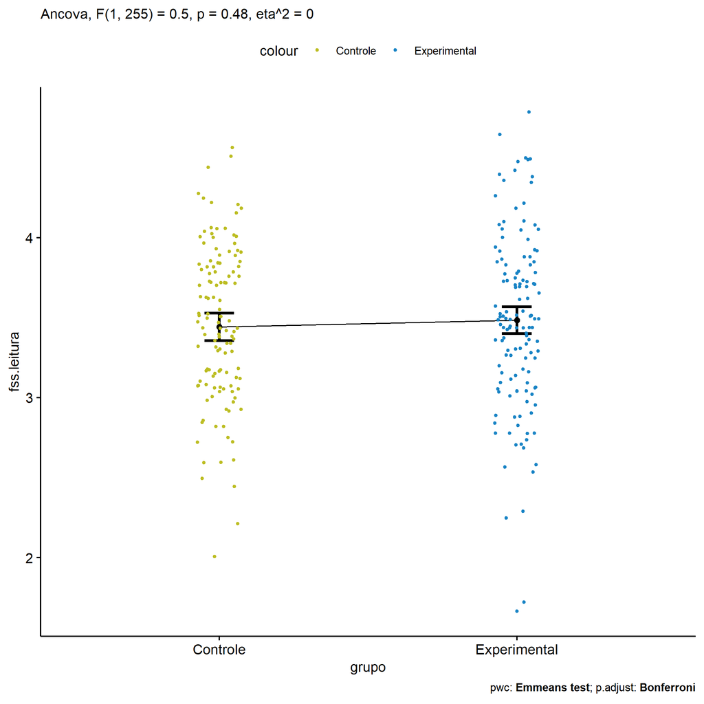

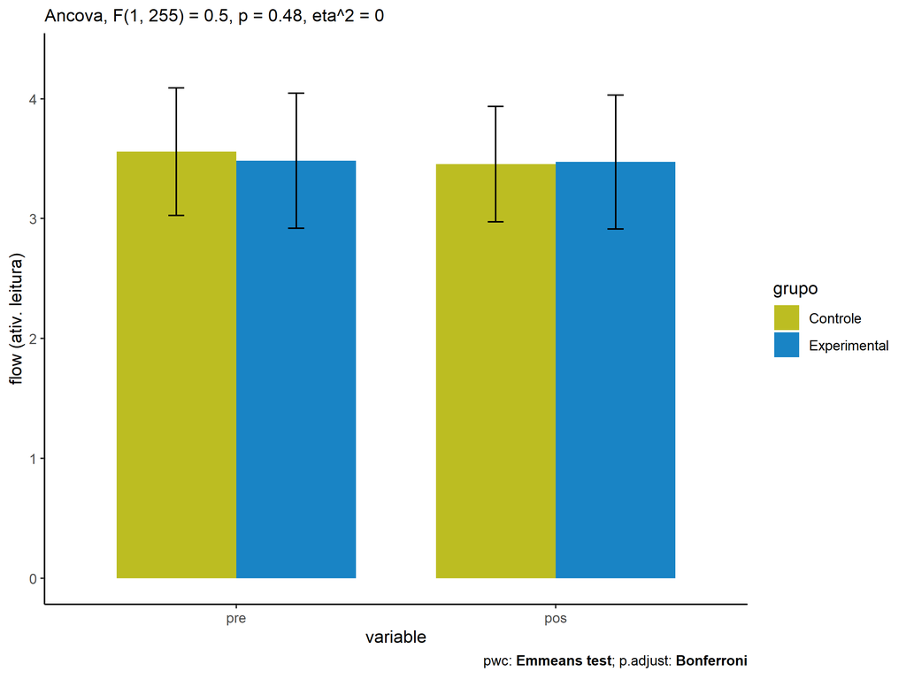

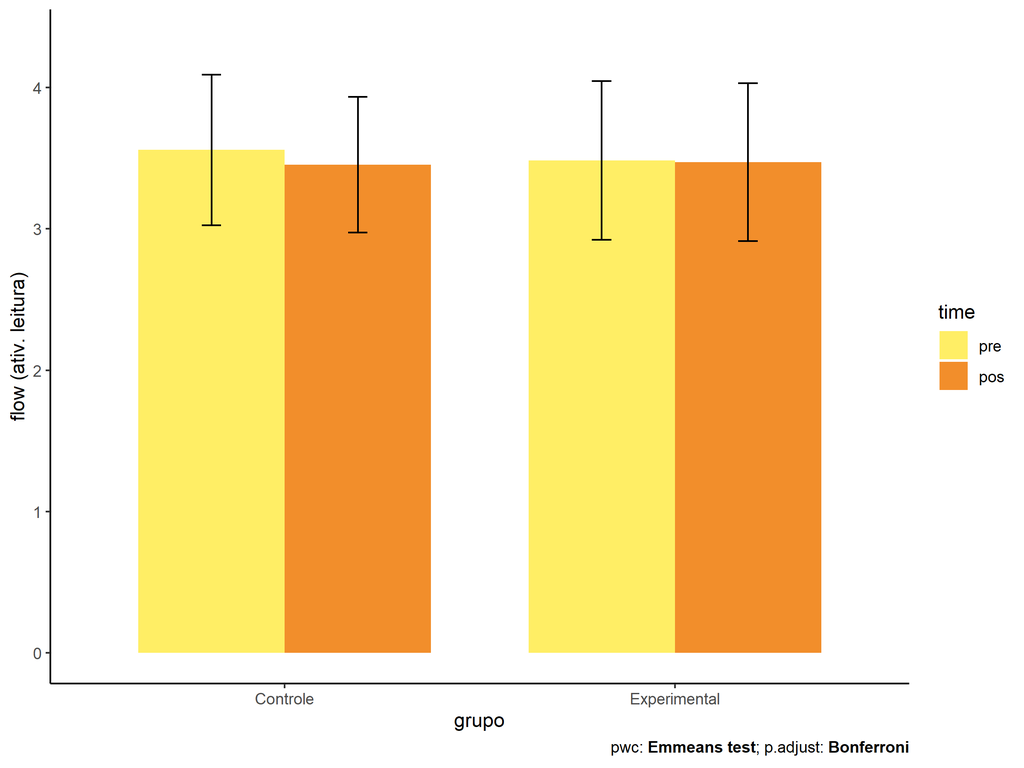

### factor: **genero**

| var | genero | n | M (pre) | SE (pre) | M (unadj) | SE (unadj) | M (adj) | SE (adj) |
| --- | --- | --- | --- | --- | --- | --- | --- | --- |
| fss.leitura | F | 117 | 3.594 | 0.049 | 3.580 | 0.044 | 3.556 | 0.045 |
| fss.leitura | M | 141 | 3.458 | 0.047 | 3.367 | 0.045 | 3.387 | 0.041 |

| .y. | group1 | group2 | estimate | conf.low | conf.high | se | statistic | p | p.adj | p.adj.signif |
| --- | --- | --- | --- | --- | --- | --- | --- | --- | --- | --- |
| fss.leitura | F | M | 0.170 | 0.050 | 0.289 | 0.061 | 2.793 | 0.006 | 0.006 | ** |
| dfs.leitura | F | M | 0.136 | 0.002 | 0.270 | 0.068 | 1.998 | 0.047 | 0.047 | * |

| .y. | genero | group1 | group2 | estimate | conf.low | conf.high | se | statistic | p | p.adj | p.adj.signif |
| --- | --- | --- | --- | --- | --- | --- | --- | --- | --- | --- | --- |
| flow.leitura | F | pre | pos | 0.014 | -0.121 | 0.150 | 0.069 | 0.208 | 0.835 | 0.835 | ns |
| flow.leitura | M | pre | pos | 0.091 | -0.033 | 0.214 | 0.063 | 1.445 | 0.149 | 0.149 | ns |

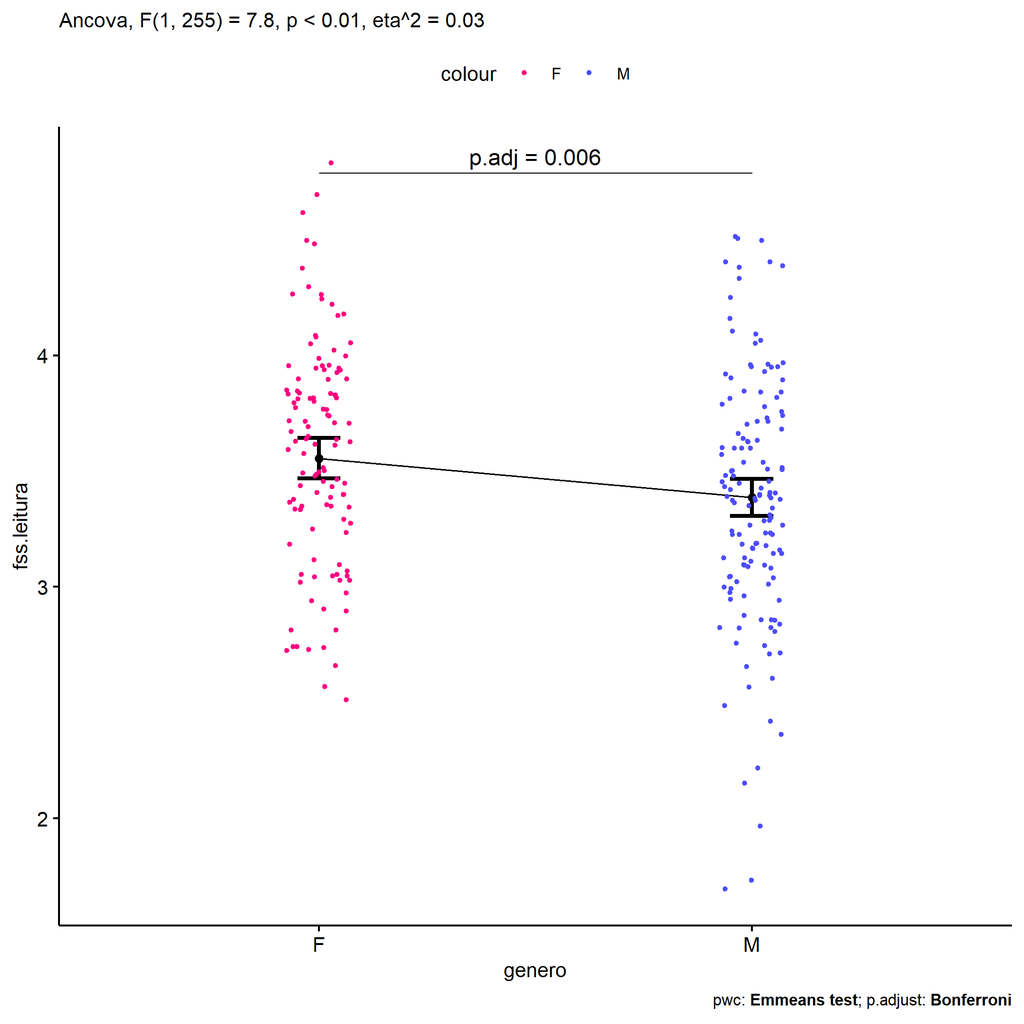

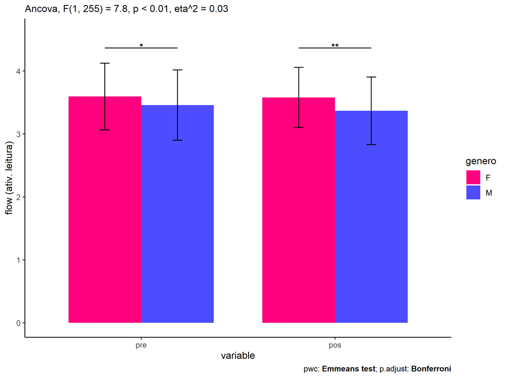

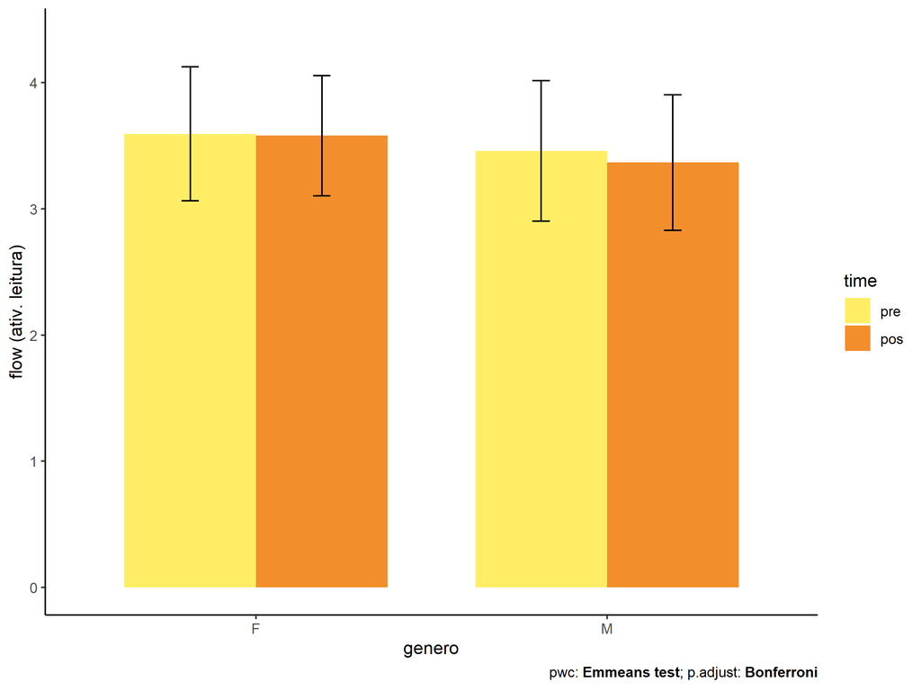

### factor: **idade**

| var | idade | n | M (pre) | SE (pre) | M (unadj) | SE (unadj) | M (adj) | SE (adj) |
| --- | --- | --- | --- | --- | --- | --- | --- | --- |
| fss.leitura | 10y | 49 | 3.472 | 0.076 | 3.480 | 0.073 | 3.502 | 0.070 |
| fss.leitura | 11y | 147 | 3.582 | 0.042 | 3.505 | 0.043 | 3.490 | 0.040 |
| fss.leitura | 12y | 34 | 3.517 | 0.105 | 3.455 | 0.090 | 3.463 | 0.083 |
| fss.leitura | 13y | 16 | 3.385 | 0.138 | 3.175 | 0.127 | 3.227 | 0.122 |

| .y. | group1 | group2 | estimate | conf.low | conf.high | se | statistic | p | p.adj | p.adj.signif |
| --- | --- | --- | --- | --- | --- | --- | --- | --- | --- | --- |
| fss.leitura | 10y | 11y | 0.013 | -0.146 | 0.171 | 0.081 | 0.157 | 0.876 | 1.000 | ns |
| fss.leitura | 10y | 12y | 0.040 | -0.174 | 0.254 | 0.109 | 0.366 | 0.714 | 1.000 | ns |
| fss.leitura | 10y | 13y | 0.275 | -0.001 | 0.552 | 0.140 | 1.965 | 0.051 | 0.304 | ns |
| fss.leitura | 11y | 12y | 0.027 | -0.155 | 0.210 | 0.093 | 0.293 | 0.770 | 1.000 | ns |
| fss.leitura | 11y | 13y | 0.263 | 0.009 | 0.516 | 0.129 | 2.043 | 0.042 | 0.253 | ns |
| fss.leitura | 12y | 13y | 0.236 | -0.055 | 0.527 | 0.148 | 1.595 | 0.112 | 0.672 | ns |
| dfs.leitura | 10y | 11y | -0.110 | -0.283 | 0.064 | 0.088 | -1.245 | 0.214 | 1.000 | ns |
| dfs.leitura | 10y | 12y | -0.045 | -0.279 | 0.190 | 0.119 | -0.376 | 0.707 | 1.000 | ns |
| dfs.leitura | 10y | 13y | 0.087 | -0.216 | 0.390 | 0.154 | 0.565 | 0.573 | 1.000 | ns |
| dfs.leitura | 11y | 12y | 0.065 | -0.135 | 0.265 | 0.102 | 0.639 | 0.524 | 1.000 | ns |
| dfs.leitura | 11y | 13y | 0.196 | -0.080 | 0.473 | 0.141 | 1.398 | 0.163 | 0.980 | ns |
| dfs.leitura | 12y | 13y | 0.132 | -0.187 | 0.450 | 0.162 | 0.813 | 0.417 | 1.000 | ns |

| .y. | idade | group1 | group2 | estimate | conf.low | conf.high | se | statistic | p | p.adj | p.adj.signif |
| --- | --- | --- | --- | --- | --- | --- | --- | --- | --- | --- | --- |
| flow.leitura | 10y | pre | pos | -0.008 | -0.217 | 0.201 | 0.106 | -0.075 | 0.940 | 0.940 | ns |
| flow.leitura | 11y | pre | pos | 0.077 | -0.043 | 0.198 | 0.061 | 1.260 | 0.208 | 0.208 | ns |
| flow.leitura | 12y | pre | pos | 0.062 | -0.189 | 0.312 | 0.128 | 0.482 | 0.630 | 0.630 | ns |
| flow.leitura | 13y | pre | pos | 0.210 | -0.155 | 0.575 | 0.186 | 1.130 | 0.259 | 0.259 | ns |

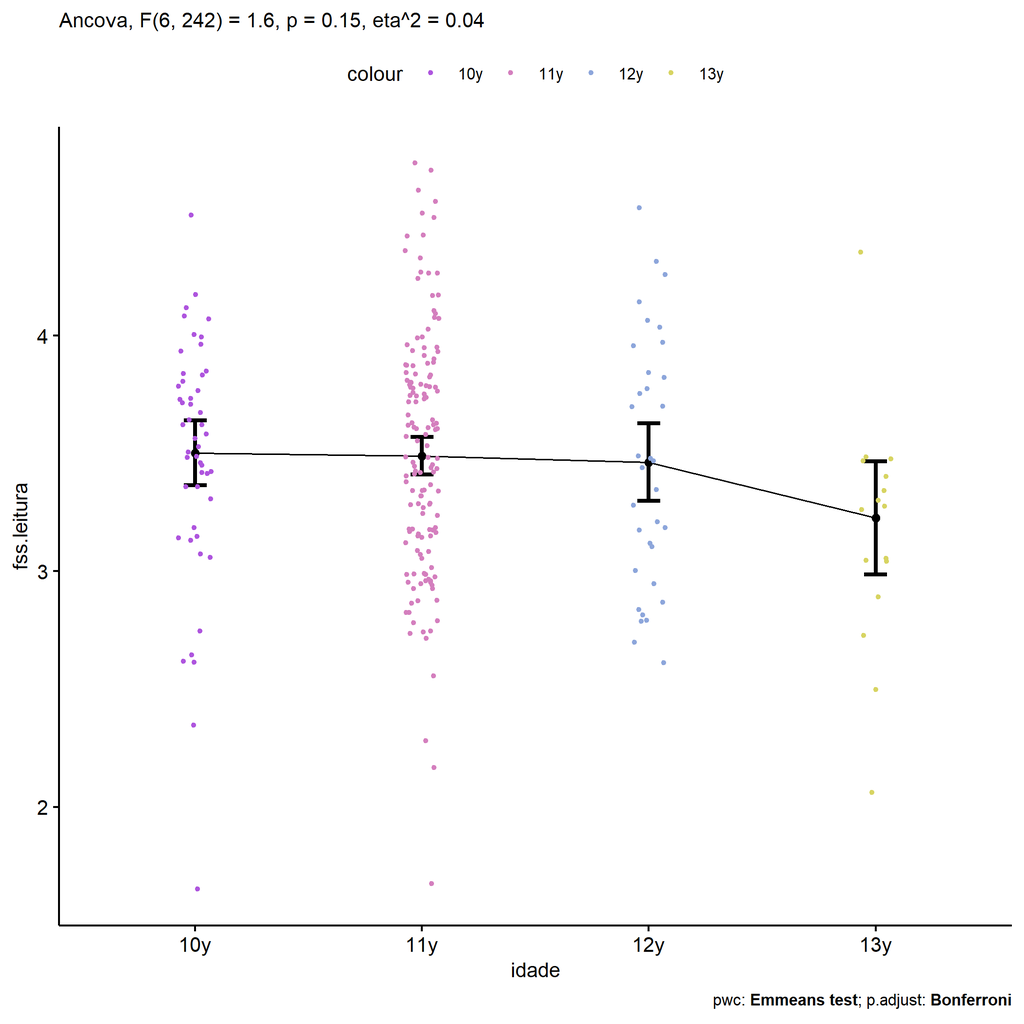

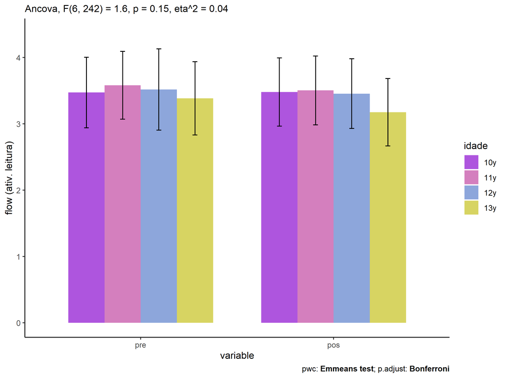

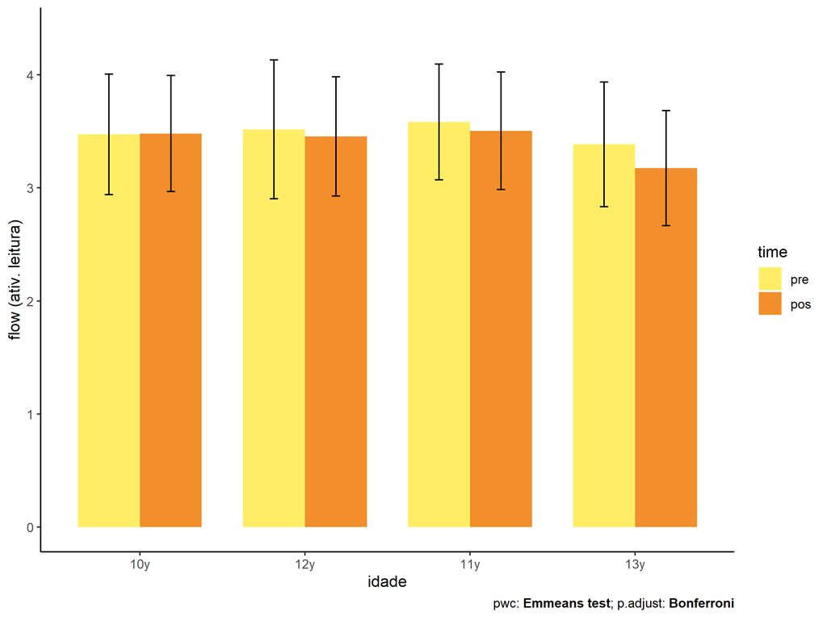

### factor: **zona.participante**

| var | zona.participante | n | M (pre) | SE (pre) | M (unadj) | SE (unadj) | M (adj) | SE (adj) |
| --- | --- | --- | --- | --- | --- | --- | --- | --- |
| fss.leitura | Rural | 96 | 3.513 | 0.054 | 3.408 | 0.057 | 3.405 | 0.050 |
| fss.leitura | Urbana | 104 | 3.498 | 0.058 | 3.478 | 0.047 | 3.480 | 0.048 |

| .y. | group1 | group2 | estimate | conf.low | conf.high | se | statistic | p | p.adj | p.adj.signif |
| --- | --- | --- | --- | --- | --- | --- | --- | --- | --- | --- |
| fss.leitura | Urbana | Rural | 0.075 | -0.063 | 0.213 | 0.07 | 1.070 | 0.286 | 0.286 | ns |
| dfs.leitura | Urbana | Rural | -0.015 | -0.172 | 0.142 | 0.08 | -0.191 | 0.849 | 0.849 | ns |

| .y. | zona.participante | group1 | group2 | estimate | conf.low | conf.high | se | statistic | p | p.adj | p.adj.signif |
| --- | --- | --- | --- | --- | --- | --- | --- | --- | --- | --- | --- |
| flow.leitura | Urbana | pre | pos | 0.020 | -0.128 | 0.168 | 0.075 | 0.266 | 0.790 | 0.790 | ns |
| flow.leitura | Rural | pre | pos | 0.106 | -0.048 | 0.259 | 0.078 | 1.350 | 0.178 | 0.178 | ns |

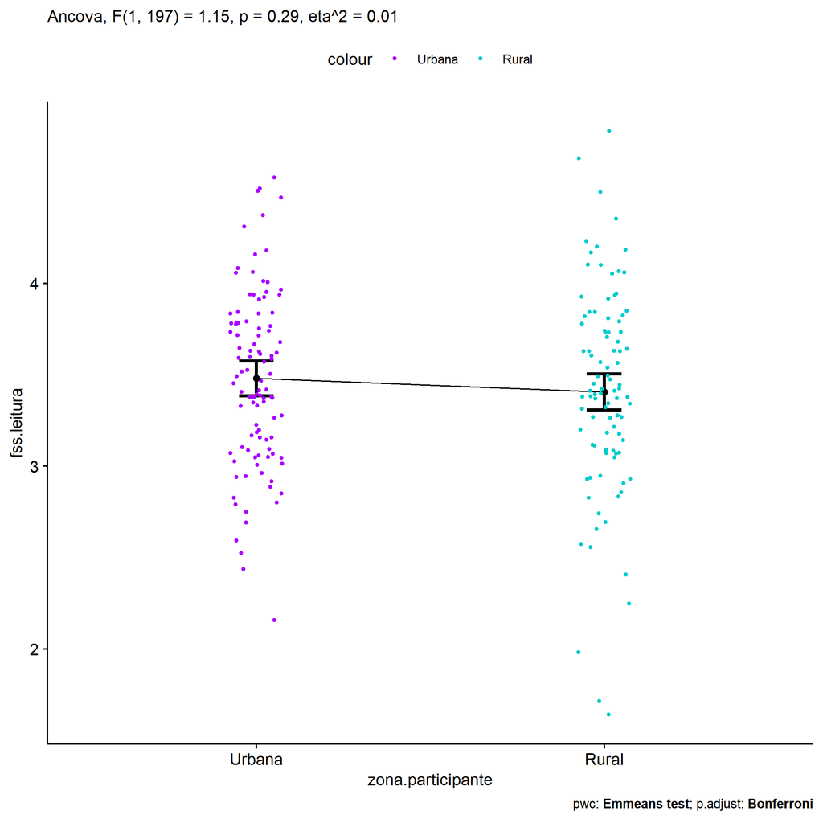

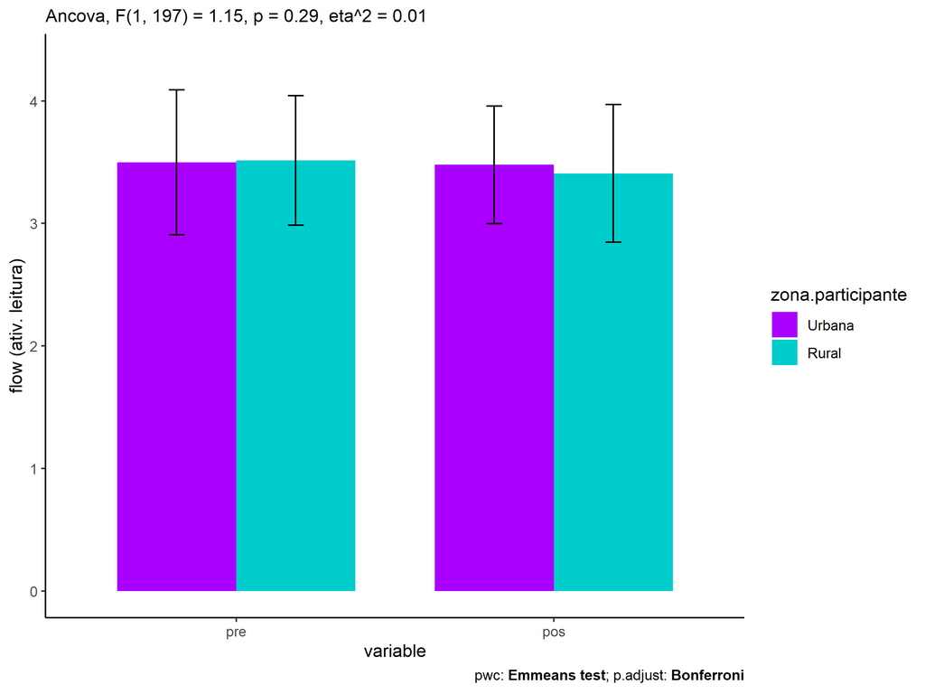

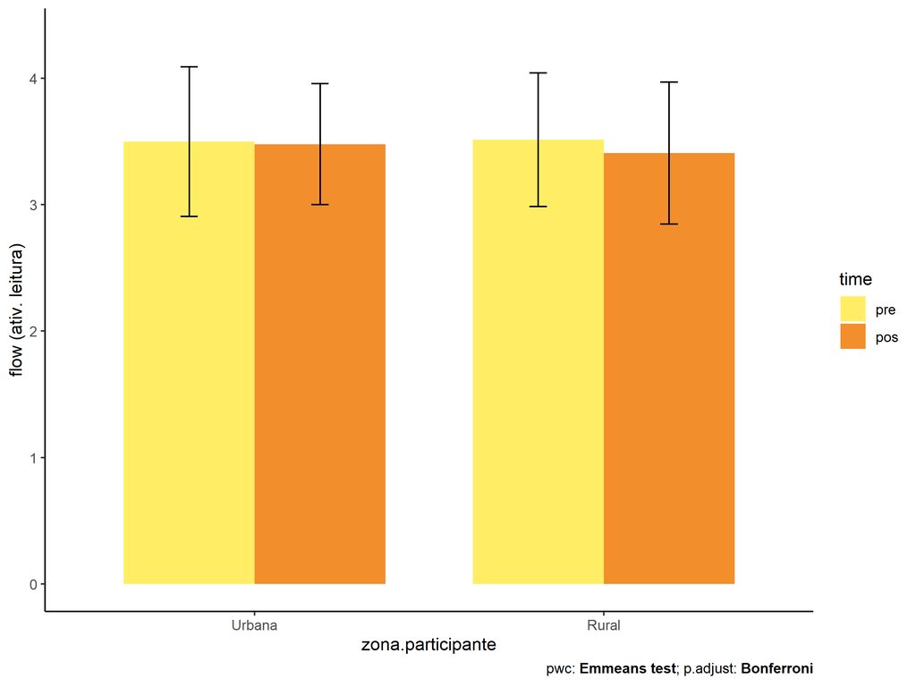

### factor: **escola**

| var | escola | n | M (pre) | SE (pre) | M (unadj) | SE (unadj) | M (adj) | SE (adj) |
| --- | --- | --- | --- | --- | --- | --- | --- | --- |
| fss.leitura | E1 | 22 | 3.196 | 0.133 | 3.574 | 0.127 | 3.694 | 0.103 |
| fss.leitura | E2 | 49 | 3.457 | 0.069 | 3.402 | 0.067 | 3.425 | 0.068 |
| fss.leitura | E3 | 30 | 3.732 | 0.094 | 3.263 | 0.099 | 3.184 | 0.088 |
| fss.leitura | E4 | 30 | 3.609 | 0.081 | 3.556 | 0.086 | 3.523 | 0.087 |
| fss.leitura | E5 | 103 | 3.481 | 0.058 | 3.460 | 0.053 | 3.474 | 0.047 |
| fss.leitura | E6 | 24 | 3.734 | 0.082 | 3.639 | 0.093 | 3.560 | 0.098 |

| .y. | group1 | group2 | estimate | conf.low | conf.high | se | statistic | p | p.adj | p.adj.signif |
| --- | --- | --- | --- | --- | --- | --- | --- | --- | --- | --- |
| fss.leitura | E1 | E2 | 0.269 | 0.026 | 0.511 | 0.123 | 2.179 | 0.03 | 0.454 | ns |
| fss.leitura | E1 | E3 | 0.510 | 0.239 | 0.780 | 0.137 | 3.714 | <0.001 | 0.004 | ** |
| fss.leitura | E1 | E4 | 0.171 | -0.097 | 0.438 | 0.136 | 1.255 | 0.211 | 1.000 | ns |
| fss.leitura | E1 | E5 | 0.219 | -0.004 | 0.442 | 0.113 | 1.936 | 0.054 | 0.809 | ns |
| fss.leitura | E1 | E6 | 0.134 | -0.150 | 0.418 | 0.144 | 0.931 | 0.353 | 1.000 | ns |
| fss.leitura | E2 | E3 | 0.241 | 0.021 | 0.461 | 0.112 | 2.160 | 0.032 | 0.476 | ns |
| fss.leitura | E2 | E4 | -0.098 | -0.317 | 0.120 | 0.111 | -0.885 | 0.377 | 1.000 | ns |
| fss.leitura | E2 | E5 | -0.049 | -0.213 | 0.114 | 0.083 | -0.598 | 0.551 | 1.000 | ns |
| fss.leitura | E2 | E6 | -0.135 | -0.371 | 0.101 | 0.120 | -1.123 | 0.263 | 1.000 | ns |
| fss.leitura | E3 | E4 | -0.339 | -0.582 | -0.096 | 0.123 | -2.750 | 0.006 | 0.096 | ns |
| fss.leitura | E3 | E5 | -0.291 | -0.487 | -0.094 | 0.100 | -2.907 | 0.004 | 0.060 | ns |
| fss.leitura | E3 | E6 | -0.376 | -0.633 | -0.118 | 0.131 | -2.876 | 0.004 | 0.066 | ns |
| fss.leitura | E4 | E5 | 0.049 | -0.147 | 0.244 | 0.099 | 0.490 | 0.624 | 1.000 | ns |
| fss.leitura | E4 | E6 | -0.036 | -0.294 | 0.221 | 0.131 | -0.279 | 0.781 | 1.000 | ns |
| fss.leitura | E5 | E6 | -0.085 | -0.300 | 0.130 | 0.109 | -0.781 | 0.436 | 1.000 | ns |
| dfs.leitura | E1 | E2 | -0.262 | -0.532 | 0.008 | 0.137 | -1.912 | 0.057 | 0.855 | ns |
| dfs.leitura | E1 | E3 | -0.536 | -0.832 | -0.241 | 0.150 | -3.580 | <0.001 | 0.006 | ** |
| dfs.leitura | E1 | E4 | -0.413 | -0.708 | -0.118 | 0.150 | -2.757 | 0.006 | 0.094 | ns |
| dfs.leitura | E1 | E5 | -0.285 | -0.532 | -0.039 | 0.125 | -2.277 | 0.024 | 0.355 | ns |
| dfs.leitura | E1 | E6 | -0.538 | -0.849 | -0.228 | 0.158 | -3.416 | <0.001 | 0.011 | * |
| dfs.leitura | E2 | E3 | -0.274 | -0.518 | -0.031 | 0.124 | -2.218 | 0.027 | 0.412 | ns |
| dfs.leitura | E2 | E4 | -0.151 | -0.395 | 0.093 | 0.124 | -1.221 | 0.223 | 1.000 | ns |
| dfs.leitura | E2 | E5 | -0.023 | -0.206 | 0.159 | 0.093 | -0.253 | 0.8 | 1.000 | ns |
| dfs.leitura | E2 | E6 | -0.276 | -0.538 | -0.014 | 0.133 | -2.078 | 0.039 | 0.581 | ns |
| dfs.leitura | E3 | E4 | 0.123 | -0.148 | 0.395 | 0.138 | 0.895 | 0.372 | 1.000 | ns |
| dfs.leitura | E3 | E5 | 0.251 | 0.033 | 0.469 | 0.111 | 2.266 | 0.024 | 0.364 | ns |
| dfs.leitura | E3 | E6 | -0.002 | -0.290 | 0.286 | 0.146 | -0.013 | 0.99 | 1.000 | ns |
| dfs.leitura | E4 | E5 | 0.128 | -0.090 | 0.346 | 0.111 | 1.153 | 0.25 | 1.000 | ns |
| dfs.leitura | E4 | E6 | -0.125 | -0.413 | 0.163 | 0.146 | -0.856 | 0.393 | 1.000 | ns |
| dfs.leitura | E5 | E6 | -0.253 | -0.491 | -0.015 | 0.121 | -2.090 | 0.038 | 0.565 | ns |

| .y. | escola | group1 | group2 | estimate | conf.low | conf.high | se | statistic | p | p.adj | p.adj.signif |
| --- | --- | --- | --- | --- | --- | --- | --- | --- | --- | --- | --- |
| flow.leitura | E1 | pre | pos | -0.378 | -0.689 | -0.067 | 0.158 | -2.389 | 0.017 | 0.017 | * |
| flow.leitura | E2 | pre | pos | 0.056 | -0.153 | 0.264 | 0.106 | 0.524 | 0.6 | 0.6 | ns |
| flow.leitura | E3 | pre | pos | 0.469 | 0.203 | 0.736 | 0.135 | 3.465 | <0.001 | <0.001 | *** |
| flow.leitura | E4 | pre | pos | 0.053 | -0.214 | 0.319 | 0.135 | 0.388 | 0.698 | 0.698 | ns |
| flow.leitura | E5 | pre | pos | 0.021 | -0.123 | 0.165 | 0.073 | 0.285 | 0.776 | 0.776 | ns |
| flow.leitura | E6 | pre | pos | 0.095 | -0.203 | 0.393 | 0.151 | 0.627 | 0.531 | 0.531 | ns |

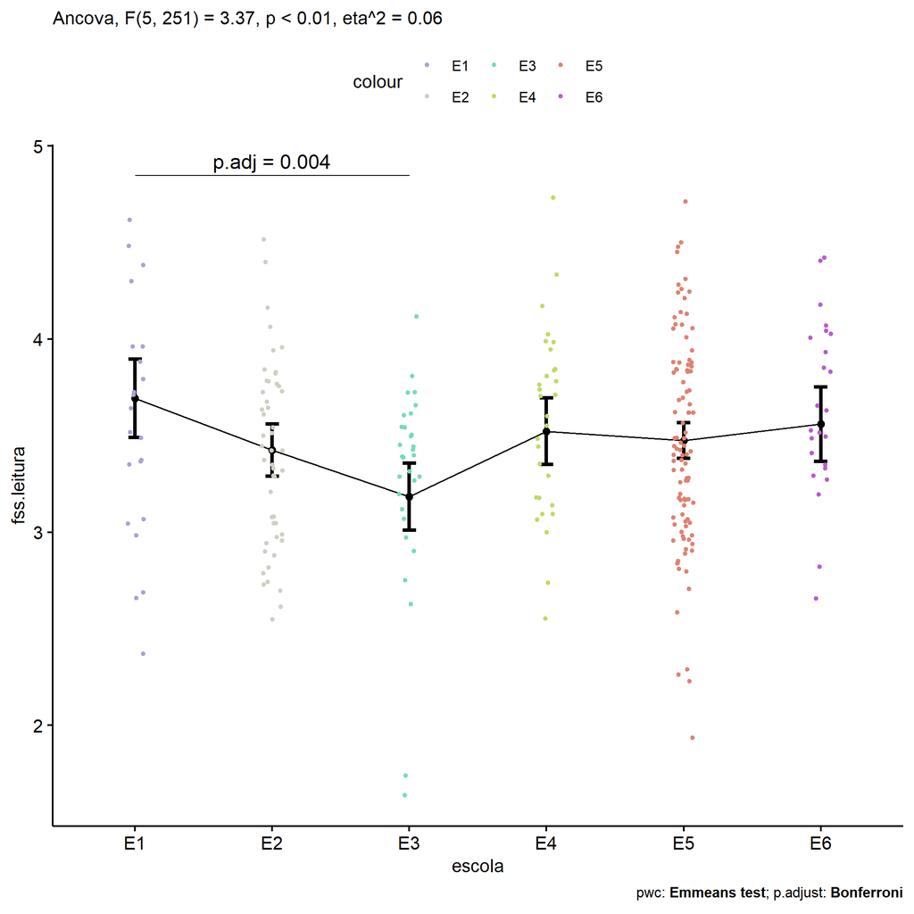

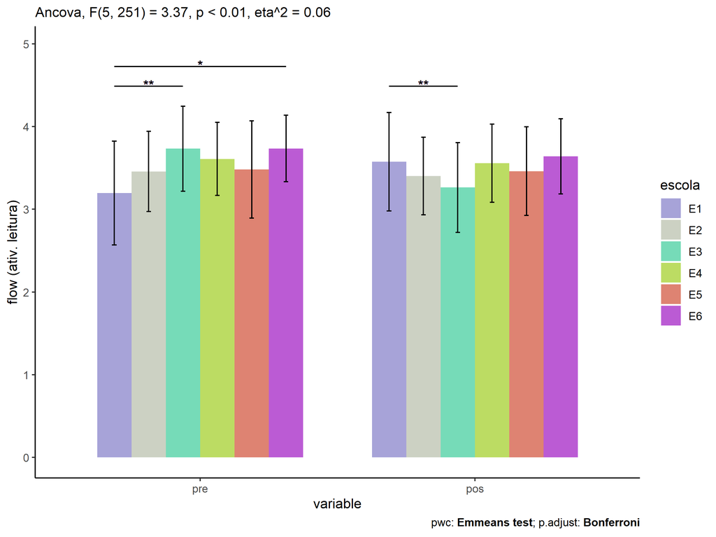

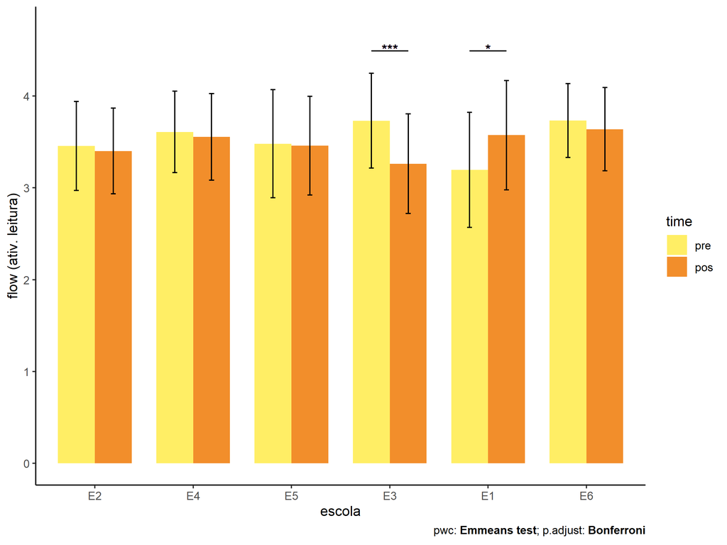

### factor: **zona.escola**

| var | zona.escola | n | M (pre) | SE (pre) | M (unadj) | SE (unadj) | M (adj) | SE (adj) |
| --- | --- | --- | --- | --- | --- | --- | --- | --- |
| fss.leitura | Rural | 84 | 3.688 | 0.050 | 3.475 | 0.056 | 3.416 | 0.054 |
| fss.leitura | Urbana | 174 | 3.438 | 0.043 | 3.458 | 0.040 | 3.486 | 0.037 |

| .y. | group1 | group2 | estimate | conf.low | conf.high | se | statistic | p | p.adj | p.adj.signif |
| --- | --- | --- | --- | --- | --- | --- | --- | --- | --- | --- |
| fss.leitura | Urbana | Rural | 0.07 | -0.06 | 0.201 | 0.066 | 1.060 | 0.29 | 0.29 | ns |
| dfs.leitura | Urbana | Rural | -0.25 | -0.39 | -0.110 | 0.071 | -3.512 | <0.001 | <0.001 | *** |

| .y. | zona.escola | group1 | group2 | estimate | conf.low | conf.high | se | statistic | p | p.adj | p.adj.signif |
| --- | --- | --- | --- | --- | --- | --- | --- | --- | --- | --- | --- |
| flow.leitura | Urbana | pre | pos | -0.020 | -0.131 | 0.092 | 0.057 | -0.349 | 0.727 | 0.727 | ns |
| flow.leitura | Rural | pre | pos | 0.214 | 0.053 | 0.374 | 0.082 | 2.617 | 0.009 | 0.009 | ** |

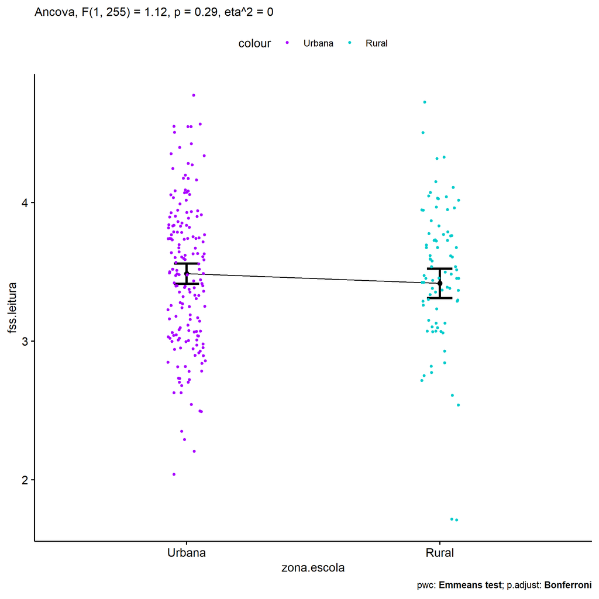

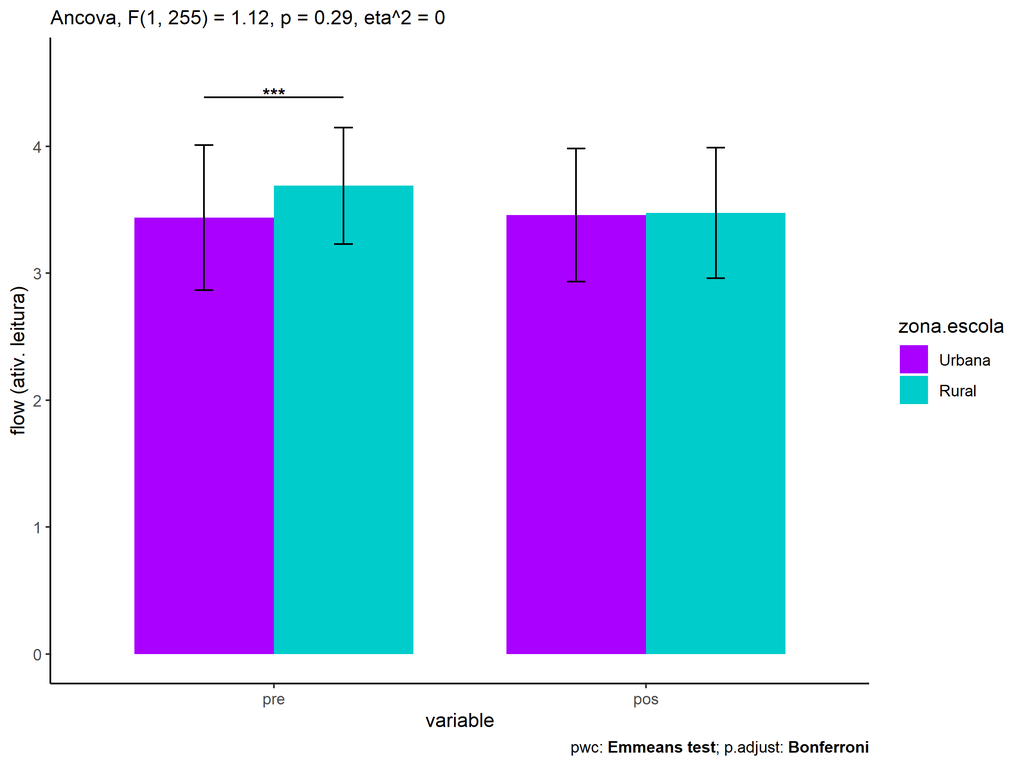

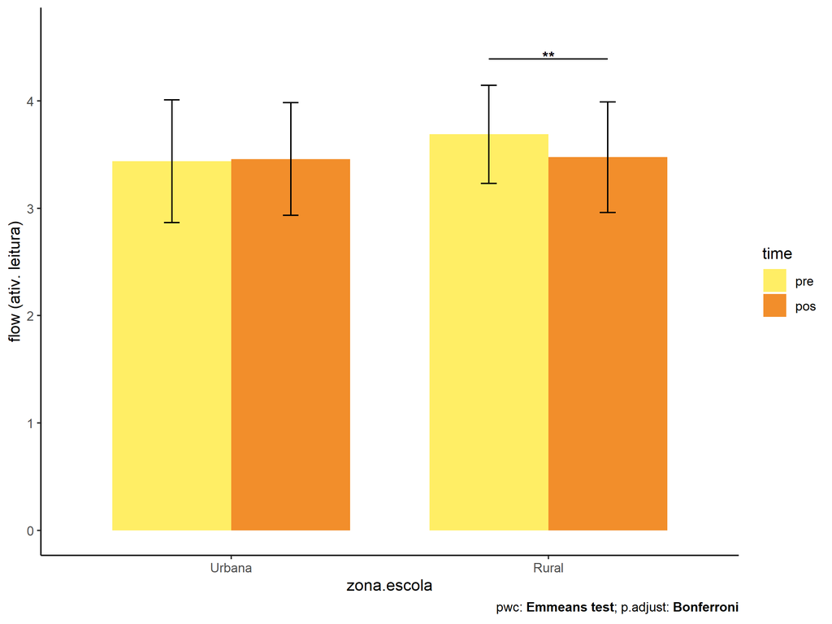